# R4DS Chapter 11 - Communication

# 11.3 Annotations

- Reference lines with `geom_hline()` and `geom_vline()`
- Rectangles for points of interest with `geom_rect()`
  - or package ggforce, `geom_mark_hull()` for subsets of groups
- `geom_segment()` + `arrow` for arrows to points
- `annotate()` for single/few annotations

> Annotation is a powerful tool for communicating main takeaways and interesting features of your visualizations. The only limit is your imagination (and your patience with positioning annotations to be aesthetically pleasing)!

## 11.3.1 Exercises

1. Use `geom_text()` with infinite positions to place text at the four corners of the plot.

Create a `tribble`/ Dataframe for the Cornerpoints to be overlaid.

```r
corners <- tribble(
  ~ label, ~x, ~y,
  "top left", -Inf, Inf,
  "top right", Inf, Inf,
  "bottom left", -Inf, -Inf,
  "bottom right", Inf, -Inf
)
```

Create a plot and add the Dataframe as layer with `geom_text()` . You have to set aesthetics separate for the text layer. Avoid grouping arguments like `color = class` in the top level. Call them in their respective geoms

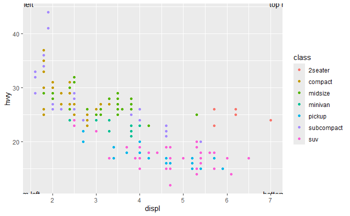

```r
ggplot(mpg, aes(displ, hwy)) +
  geom_point(aes(color = class)) +
  geom_text(data = corners,
            aes(x, y, label = label))
```

Labels are center position by default. Try `hjust` and `vjust` arguments.

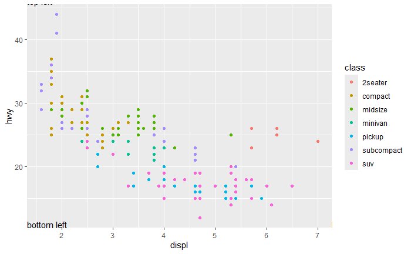

```r
ggplot(mpg, aes(displ, hwy)) +
  geom_point(aes(color = class)) +
  geom_text(
    data = corners,
    aes(
      x,
      y,
      label = label,
      hjust = "left",
      vjust = "bottom")
  )
```

Works only for a single corner. Add individual justification to tribble.

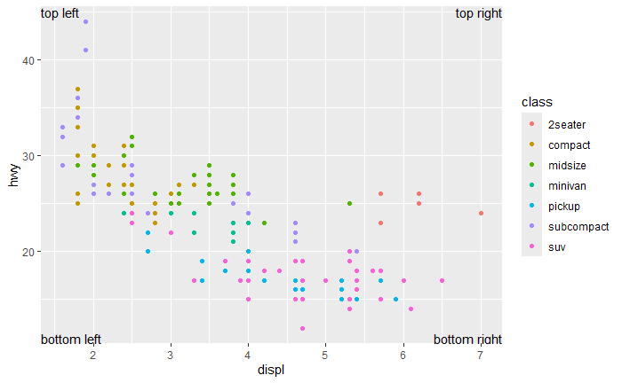

```r
corners <- tribble(
  ~label, ~x, ~y, ~hjust, ~vjust,
  "top left", -Inf, Inf, "bottom", "right",
  "top right", Inf, Inf, "top", "right",
  "bottom left", -Inf, -Inf, "bottom", "left",
  "bottom right", Inf, -Inf, "top", "left",
)

ggplot(mpg, aes(displ, hwy)) +
  geom_point(aes(color = class)) +
  geom_text(
    data = corners,
    aes(
      x,
      y,
      label = label,
      hjust = hjust,
      vjust = vjust)

  )
```

Values instead of strings for vjust, to fully show the bottom right “g”.

Leave `hjust` as string, to not have to adjust for differences in text length.

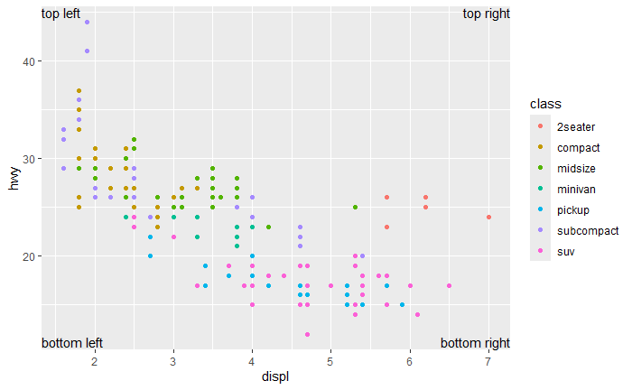

```r
corners <- tribble(
  ~label, ~x, ~y, ~hjust, ~vjust,
  "top left", -Inf, Inf, "left", 1,
  "top right", Inf, Inf, "right", 1,
  "bottom left", -Inf, -Inf, "left", -.25,
  "bottom right", Inf, -Inf, "right", -.25,
)

ggplot(mpg, aes(displ, hwy)) +
  geom_point(aes(color = class)) +
  geom_text(
    data = corners,
    aes(
      x,
      y,
      label = label,
      hjust = hjust,
      vjust = vjust)

  )
```

# 11.4 Scales—-

## Load librarys—-

```r
library(tidyverse)
library(scales)
library(ggrepel)
library(patchwork)
```

## 11.4.1 Default scales—-

```r
ggplot(mpg, aes(x = displ, y = hwy)) +
  geom_point(aes(color = class))
```

```r
# the same as
ggplot(mpg, aes(x = displ, y = hwy)) +
  geom_point(aes(color = class)) +
  scale_x_continuous() +
  scale_y_continuous() +
  scale_color_discrete()
```

#>collectively axes and legends are called #>**guides**

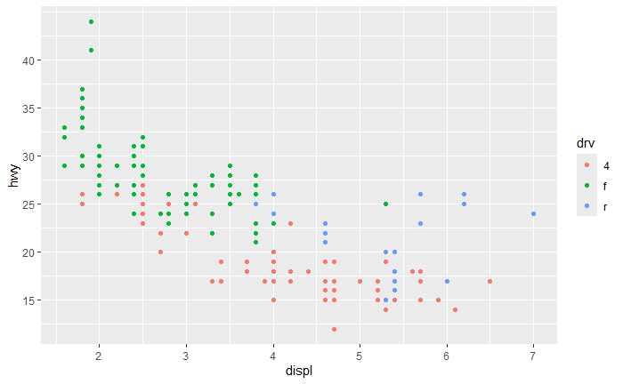

```r
ggplot(mpg, aes(x = displ, y = hwy, color = drv)) +
  geom_point() +
  scale_y_continuous(breaks = seq(15, 40, by = 5))
```

## 11.4.3 Legend layout—-

```r
base <- ggplot(mpg, aes(x = displ, y = hwy)) +
  geom_point(aes(color = class))

base + theme(legend.position = "right")
```

[output not shown]

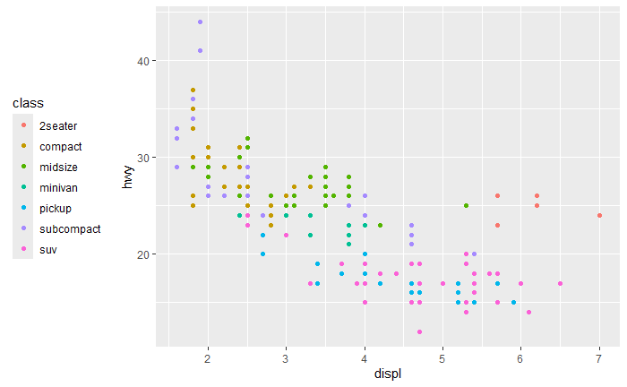

```r
base + theme(legend.position = "left")
```

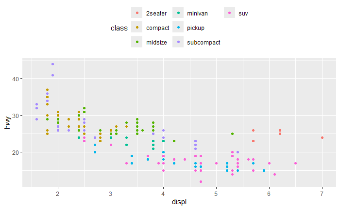

```r
base +
  theme(legend.position = "top") +
  guides(color = guide_legend(nrow = 3))
```

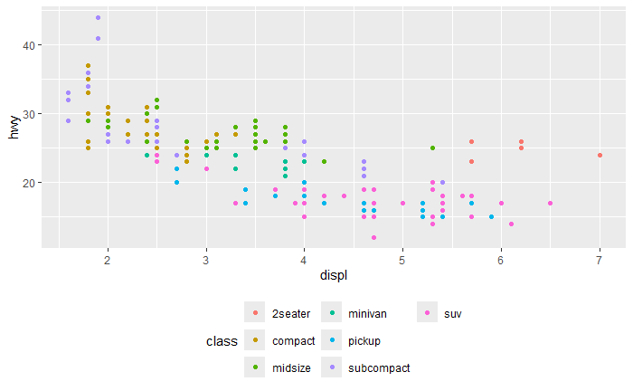

```r
base +
  theme(legend.position = "bottom") +
  guides(color = guide_legend(nrow = 3))
```

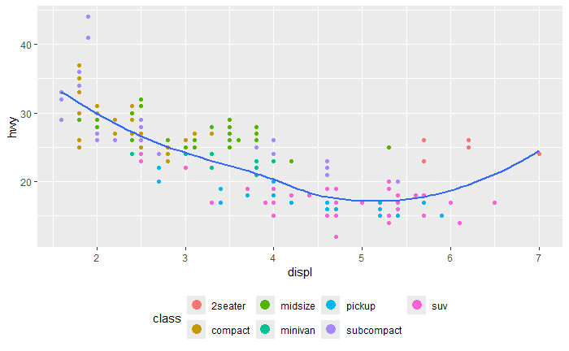

```r
ggplot(mpg, aes(x = displ, y = hwy)) +
  geom_point(aes(color = class)) +
  geom_smooth(se = FALSE) +
  theme(legend.position = "bottom") +
  guides(color = guide_legend(nrow = 2, override.aes = list(size = 4)))
```

# 11.4.4 Replacing a scale ————————————————

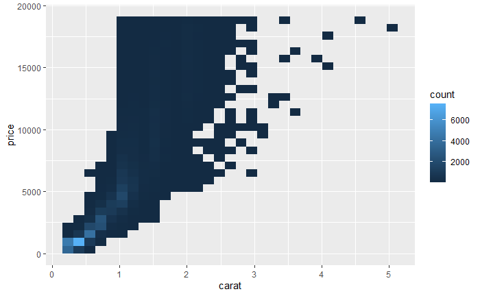

```r
ggplot(diamonds, aes(x = carat, y = price)) +
  geom_bin2d()
```

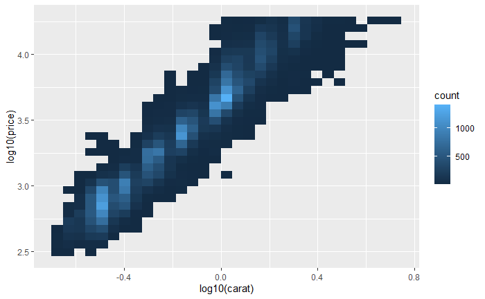

```r
ggplot(diamonds, aes(x = log10(carat), y = log10(price))) +
  geom_bin2d()
```

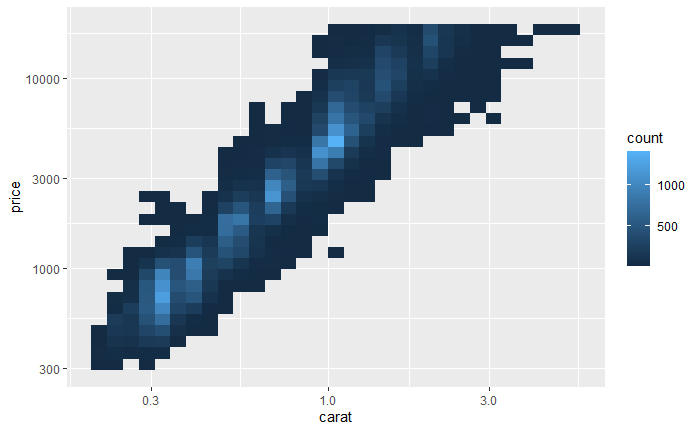

```r
ggplot(diamonds, aes(x = carat, y = price)) +
  geom_bin_2d() +
  scale_x_log10() +
  scale_y_log10()
```

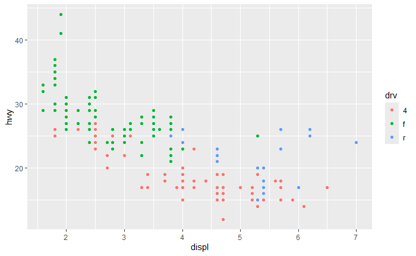

```r
ggplot(mpg, aes(x = displ, y = hwy)) +
  geom_point(aes(color = drv))
```

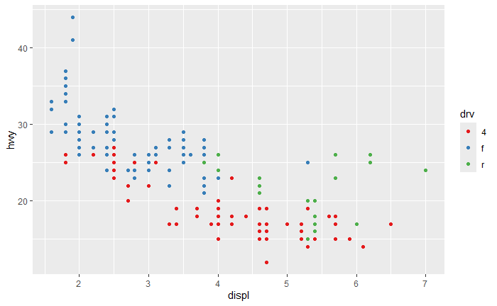

```r
ggplot(mpg, aes(x = displ, y = hwy)) +
  geom_point(aes(color = drv)) +
  scale_color_brewer(palette = "Set1")
```

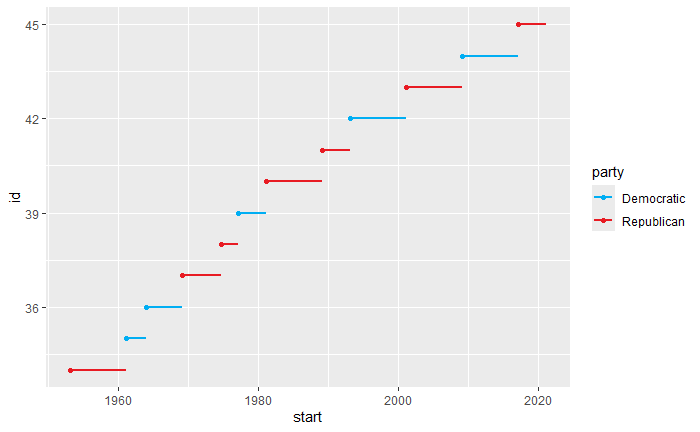

```r
presidential |>
  mutate(id = 33 + row_number()) |>
  ggplot(aes(x = start, y = id, color = party)) +
  geom_point() +
  geom_segment(aes(xend = end, yend = id), linewidth = 1) +
  scale_color_manual(values = c(Republican = "#E81B23", Democratic = "#00AEF3"))
```

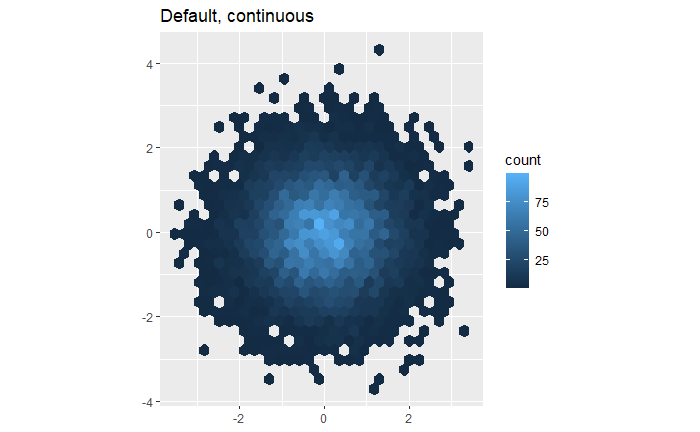

```r
df <- tibble(
  x = rnorm(10000),
  y = rnorm(10000)
)

ggplot(df, aes(x, y)) +
  geom_hex() +
  coord_fixed() +
  labs(title = "Default, continuous", x = NULL, y = NULL)
```

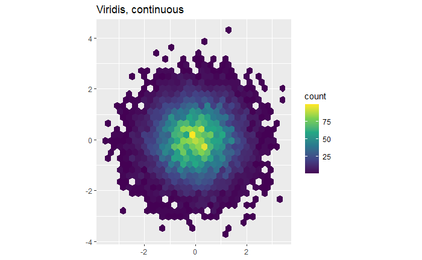

```r
ggplot(df, aes(x, y)) +
  geom_hex() +
  coord_fixed() +
  scale_fill_viridis_c() +
  labs(title = "Viridis, continuous", x = NULL, y = NULL)
```

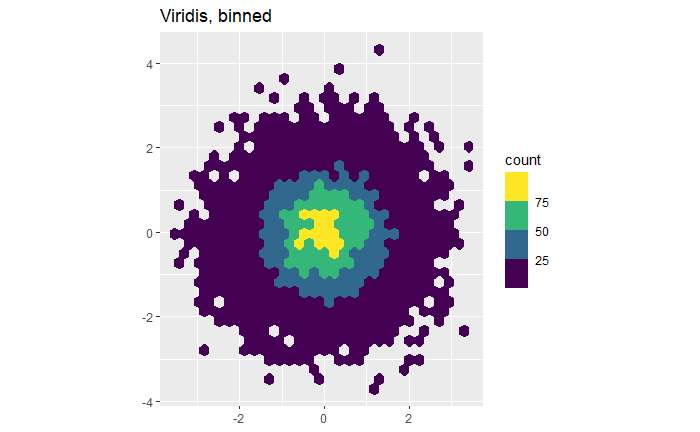

```r
ggplot(df, aes(x, y)) +
  geom_hex() +
  coord_fixed() +
  scale_fill_viridis_b() +
  labs(title = "Viridis, binned", x = NULL, y = NULL)
```

# 11.4.6 Exercises

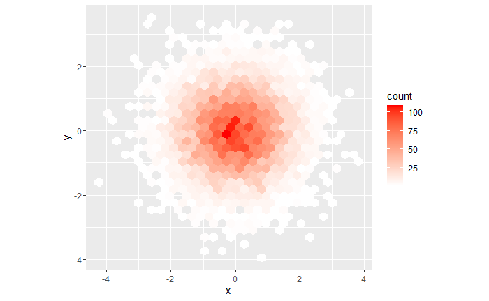

```r
df <- tibble(
  x = rnorm(10000),
  y = rnorm(10000)
)

ggplot(df, aes(x, y)) +
  geom_hex() +
  scale_fill_gradient(low = "white", high = "red") +
  coord_fixed()
```

2. What is the first argument to every scale? How does it compare to `labs()`? The first argument of the scale_ prompts is name, as opposed to title for the `lab()`prompt. Because for each object exists a singular scale prompt the first argument can be the name, whereas with `labs()` each argument considers another object.
3. Change the display of the presidential terms by:
1. combining the two variants that customize colors and x axis breaks

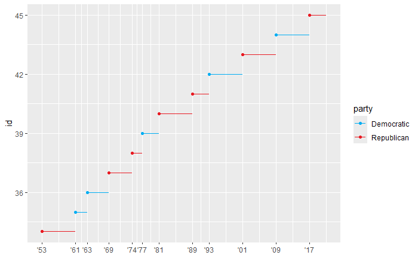

```r
presidential |>
  mutate(id = 33 + row_number()) |>
  ggplot(aes(x = start, y = id, color = party)) +
  geom_point() +
  geom_segment(aes(xend = end, yend = id)) +
  scale_color_manual(values = c(Republican = "#E81b23", Democratic = "#00Aef3")) +
  scale_x_date(name = NULL, date_labels = "'%y", breaks = presidential$start)
```

2. improving the display of the y axis

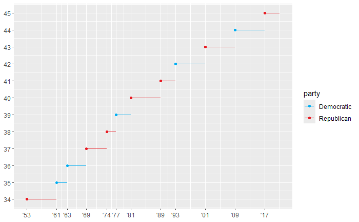

```r
presidential |>
  mutate(id = 33 + row_number()) |>
  ggplot(aes(x = start, y = id, color = party)) +
  geom_point() +
  geom_segment(aes(xend = end, yend = id)) +
  scale_color_manual(values = c(Republican = "#E81b23", Democratic = "#00Aef3")) +
  scale_x_date(name = NULL, date_labels = "'%y", breaks = presidential$start) +
  scale_y_continuous(
    name = NULL,
    breaks = seq(33, 45, by = 1)
  )
```

3. labelling each term with the name of the president

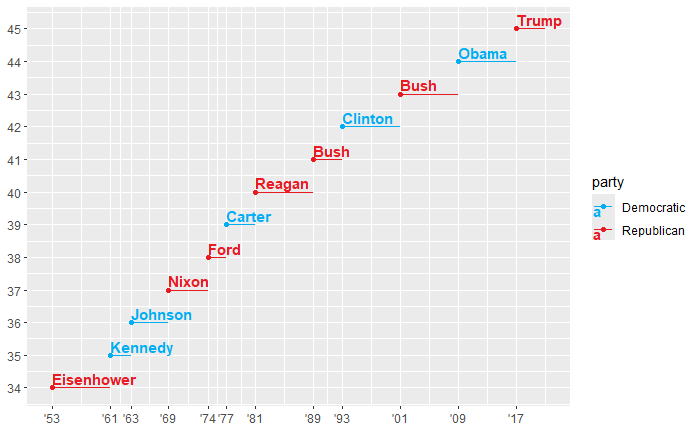

```r
presidential |>
  mutate(id = 33 + row_number()) |>
  ggplot(aes(x = start, y = id, color = party)) +
  geom_point() +
  geom_segment(aes(xend = end, yend = id)) +
  scale_color_manual(values = c(Republican = "#E81b23", Democratic = "#00Aef3")) +
  scale_x_date(name = NULL, date_labels = "'%y", breaks = presidential$start) +
  scale_y_continuous(name = NULL, breaks = seq(33, 45, by = 1)) +
  geom_text(
    aes(label = name),
    hjust = "left",
    vjust = "bottom",
    fontface = "bold",
    nudge_y = .1)
```

4. adding informative plot labels [todo]

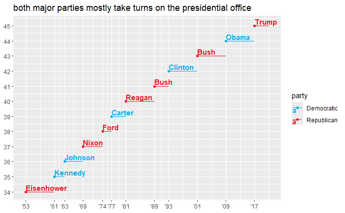

```r
presidential |>
  mutate(id = 33 + row_number()) |>
  ggplot(aes(x = start, y = id, color = party)) +
  geom_point() +
  geom_segment(aes(xend = end, yend = id)) +
  scale_color_manual(values = c(
    Republican = "#E81b23",
    Democratic = "#00Aef3"
  )) +
  scale_x_date(name = NULL,
               date_labels = "'%y",
               breaks = presidential$start) +
  scale_y_continuous(name = NULL, breaks = seq(33, 45, by = 1)) +
  geom_text(
    aes(label = name),
    hjust = "left",
    vjust = "bottom",
    fontface = "bold",
    nudge_y = .1
  ) +
  labs(
    title = "both major parties mostly take turns on the presidential office",
    label = "Test"

  )
```

5. placing breaks every 4 years (this is trickier than it seems!).
4. First create the follwing plot. Then, modify the code using `override.aes`to make the legend easier to see.

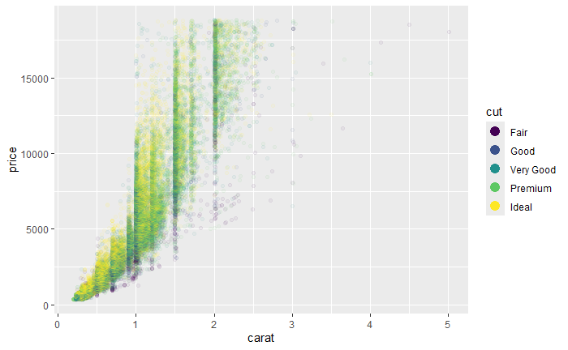

```r
# guides is the control for individual legends
# guide_legend for categorical, guide_colorbar for continuous
# override.aes to free legend from plot aesthetics
ggplot(diamonds, aes(x = carat, y = price)) +
  geom_point(aes(color = cut), alpha = 1/20) +
  guides(color = guide_legend(override.aes = list(size = 4, alpha = 1)))
```

## 11.5 Themes

```r
ggplot(diamonds, aes(x = carat, y = price)) +
  geom_point(aes(color = cut), alpha = 1/20) +
  theme_solarized_2() +
  guides(color = guide_legend(override.aes  = list(size = 4, alpha = 1)))
```

[output not shown]

2. Make the axis labels of your plot blue and bolded.